# Mapping Btnl[1,4,6] Genes to Intestinal Villus Axis Expression Data: Moor *et. al.*

philip.east@crick.ac.uk

Compiled: 09 April, 2020 @ 15:15:31

```r
library( Seurat )
library( ggplot2 )
library( tidyverse )
set.seed( 1000 )
```

```r
my_grey <- "#707173"
my_red <- "#e3001a"
my_blue <- "#4066aa"

plot_formatter <- function() {
    theme_bw( ) +
        theme( panel.grid.major = element_blank( ),
               panel.grid.minor = element_blank( ),
               panel.border = element_blank( ),
               panel.background = element_blank( ),
               text = element_text( size = 10 ) )
}
```

# Introduction

Presented here is a re-analysis of scRNA-Seq data from [Moor et. al.](https://www.sciencedirect.com/science/article/pii/S0092867418311644?via%3Dihub) ‘Spatial Reconstruction of Single Enterocytes Uncovers Broad Zonation along the Intestinal Villus Axis’. We show the expression patterns of specific Btnl genes (Btnl1,4 & 6) in the different villus segments reported in Moor *et. al.*

## scRNA-Seq data

The raw data can be found at GSE109413. There are two replicate cell sets. A processed form of the data, including Seurat objects, cell t-SNE coordinates and cell villus region definitions can be found at https://zenodo.org/record/1400090.

# Btln Genes

We are interested in Btnl1/4/6.

```r
genes <- c( "Btnl1", "Btnl4", "Btnl6" )
```

## Read in data

The processed data contains a combined seurat object in file csc.combined_seurat.Rda. This is the object we are using for the Btln[x] expression values. There is also a file named table_C_scRNAseq_tsne_coordinates_zones.tsv which contains published t-SNE coordinates and villus region definitions.

```r
load( file = "csc.combined_seurat.Rda" )
srat_obj <- UpdateSeuratObject( csc.combined )
srat_obj
```

```
## An object of class Seurat
## 27998 features across 1568 samples within 1 assay
## Active assay: RNA (27998 features)
##  2 dimensional reductions calculated: pca, tsne
```

```r
tsne_df <- read.delim( file = "table_C_scRNAseq_tsne_coordinates_zones.tsv" )

srat_obj@meta.data <- srat_obj@meta.data %>%
    rownames_to_column( var = "cell_id" ) %>%
    mutate( cell_id_tmp = cell_id ) %>%
    left_join( tsne_df, by = "cell_id" ) %>%
    column_to_rownames( var = "cell_id_tmp" )
srat_obj <- srat_obj[ ,!is.na( srat_obj$zone ) ]
```

## t-SNE

We use the t-SNE coordinates published above to construct a t-SNE projection.

## Villus regions

Here we see the t-SNE plot with villus regions highlighted. This recapitulates figure 2D in Moor *et. al.*

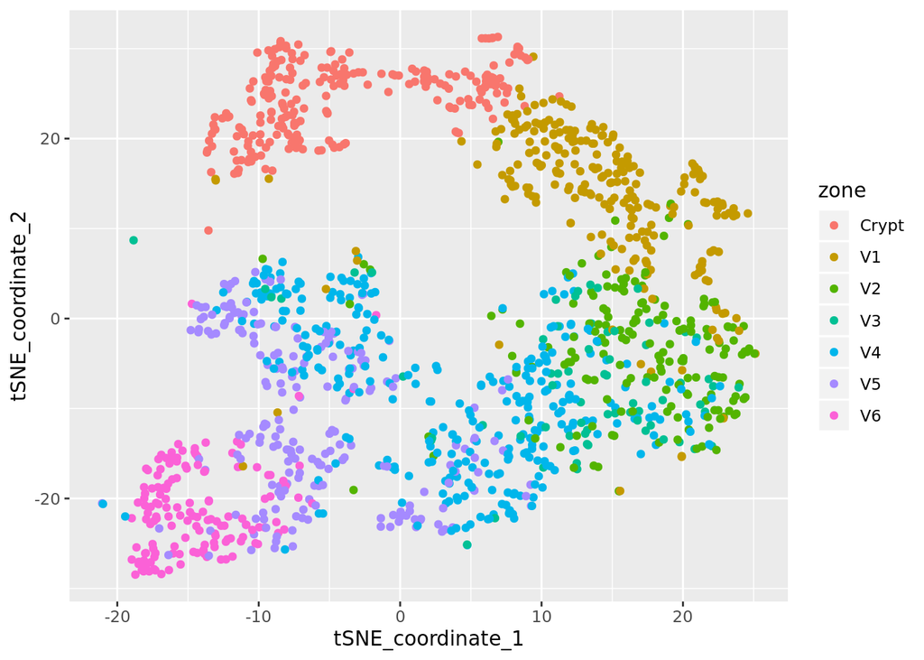

```r
gg_tsne <- srat_obj@meta.data %>%
    ggplot( aes ( x = tSNE_coordinate_1, y = tSNE_coordinate_2, color = zone ) ) +
    geom_point()
gg_tsne
```

## DotPlot

The expression of Btnl genes are also shown per villus region in the dotplot below. The colour represents the mean expression across the cells within the villus region. The size of the dot shows the percentage of expressing cells within the region. The mean expression values per cell group are z-score scaled.

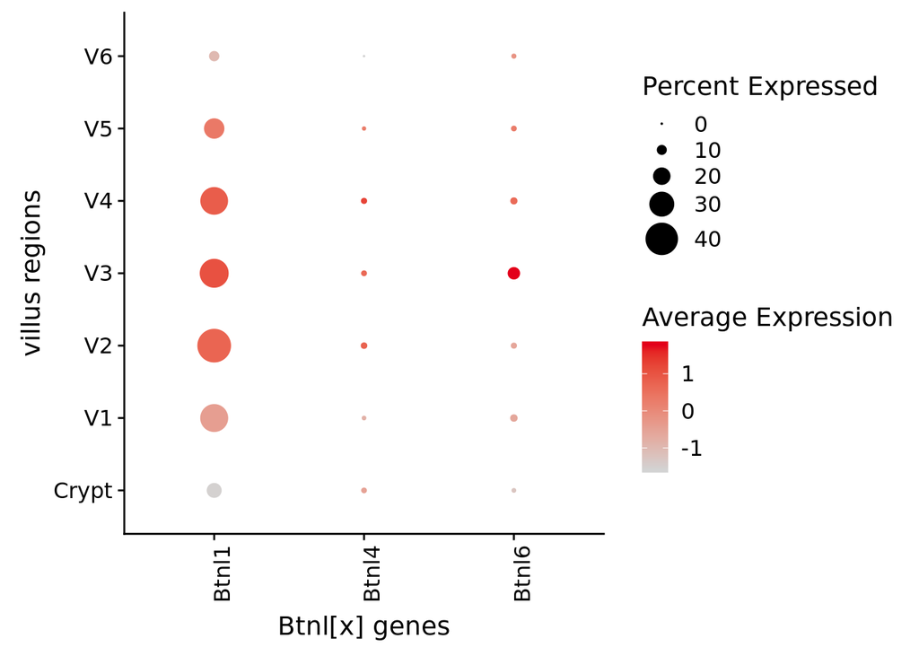

```r
dp <- DotPlot( srat_obj, features = rev( genes ),
                  cols = c( "lightgrey", my_red ),
                  dot.scale = 8,
                  group.by = "zone" ) +
    labs( y = "villus regions", x = "Btnl[x] genes" ) +
    theme( axis.text.x = element_text( angle = 90, hjust = 1 ) )
print( dp )
```

## Profile plots

Below we see mean z-score Btnl gene expression profiles across the villus regions. The blue ribbon indicates the standard error in expression across the cells from each region.

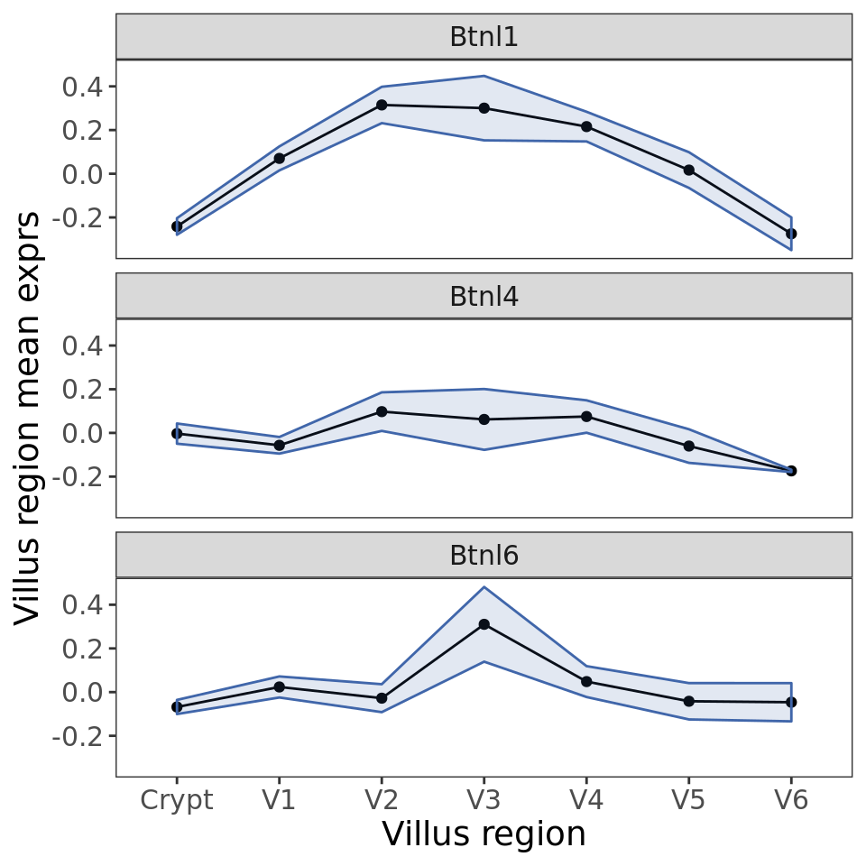

```r
btln_exprs_norm <- GetAssayData( srat_obj, slot = "scale.data" )[ genes, ] %>%
    as.data.frame( ) %>%
    rownames_to_column( var = "gsymbol" ) %>%
    gather( cell_id, exprs, -gsymbol ) %>%
    spread( gsymbol, exprs )

profile_plotdat <- srat_obj@meta.data %>%
    dplyr::select( cell_id, zone ) %>%
    left_join( btln_exprs_norm, by = "cell_id" ) %>%
    gather( gene, exprs, -cell_id, -zone ) %>%
    group_by( gene, zone ) %>%
    dplyr::summarize( zone_mean = mean( exprs ),
                     zone_se = sd( exprs ) / sqrt( length( exprs ) ) )

gg_profile <- profile_plotdat %>%
    filter( gene %in% genes ) %>%
    ggplot( aes( x = zone, y = zone_mean, ymax = zone_mean + zone_se, ymin = zone_mean - zone_se, group = gene ) ) +
    geom_line( ) +
    geom_point( ) +
    geom_ribbon( alpha = 0.15, color = my_blue, fill = my_blue ) +
    facet_wrap( ~gene, ncol = 1 ) +
    labs( y = "Villus region mean exprs", x = "Villus region" ) +
    theme_bw( ) +
    theme( panel.grid.major = element_blank( ),
          panel.grid.minor = element_blank( ),
          panel.background = element_blank( ),
          text = element_text( size = 14 ) )
print( gg_profile )
```